# Machine_Learning_Project

Silverio Neves

29 de Outubro de 2018

# Executive Summary

In this project, we use data (a) from accelerometers on the belt, forearm, arm, and dumbell of 6 participants. They were asked to perform barbell lifts correctly and incorrectly in 5 different ways. **The goal** of the project is to predict the manner in which they did the exercise. This is the “classe” variable. We do a prediction using 20 different test cases in the model. For the prediction model we it was the FCA and Random Forest with great sucess.

*(a)Velloso, E.; Bulling, A.; Gellersen, H.; Ugulino, W.; Fuks, H. Qualitative Activity Recognition of Weight Lifting Exercises. Proceedings of 4th International Conference in Cooperation with SIGCHI (Augmented Human ’13) . Stuttgart, Germany: ACM SIGCHI, 2013. (http://groupware.les.inf.puc-rio.br/har)*

# Load and cleaning data

We will download and load file for training and test.

```r
## download files
if(!file.exists("pml-training.csv")) download.file("https://d396qusza40orc.cloudfront.net/predmachlearn/pml-training.csv", "pml-training.csv" )
if(!file.exists("pml-testing.csv"))
download.file("https://d396qusza40orc.cloudfront.net/predmachlearn/pml-testing.csv", "pml-testing.csv" )
## load dataset
tr <- read.csv("pml-training.csv", na.strings = c("#DIV/0!","NA"))
ts <- read.csv("pml-testing.csv", na.strings = c("#DIV/0!","NA"))
## dataset properties
trHeads <- names(tr)
tsHeads <- names(ts)
```

The **outcome variable CLASS** has a class of factor with the following factors and their number of occurences in the dataset

```r
summary(tr$classe)
```

```
##    A    B    C    D    E
## 5580 3797 3422 3216 3607
```

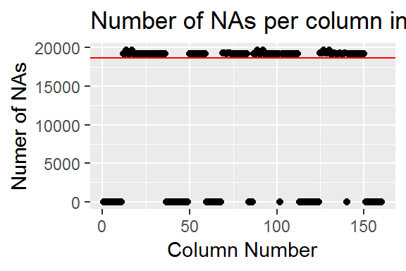

```r
rowswithoutNA <- rowSums(is.na(tr))
rowswithoutNA <- sum(rowswithoutNA==0)

NA_Col <- data.frame(Colnumber = 1:dim(tr)[2], ColNANumber = colSums(is.na(tr)))

ncol95NA <- sum(colSums(is.na(tr))>=dim(tr)[1]*0.95)

g1 = ggplot(data = NA_Col, aes(x = Colnumber, y = ColNANumber))
g1 = g1 + geom_point(show.legend = FALSE)
g1 = g1 + geom_hline(yintercept = dim(tr)[1]*.95, color = "red")
g1 = g1 + labs(title = "Number of NAs per column in training data set", y = "Numer of NAs",x = "Column Number")
g1
```

```r
predictorstoremove <- as.vector(names(tr)[colSums(is.na(tr))>=dim(tr)[1]*0.95])
trclean <- tr[,-which(names(tr) %in% predictorstoremove)]
tsclean <- ts[,-which(names(ts) %in% predictorstoremove)]
```

Exploring the training dataset it shoes us that there are **0 rows** without NA presence and there a **100 predictors** with more than 95% of their observations values with NAs. So these predictors should be ignored in the training and testing datasets.

The first 6 variables seems to be related with row identifcation **X**, user identification **user_name** and time register **raw_timestamp_part_1, raw_timestamp_part_2, cvtd_timestamp, new_window**. So they are not important for the outcome **classe**. So we will remove it from the two datasets.

```r
str(trclean[,1:6])
```

```
## 'data.frame':    19622 obs. of  6 variables:
##  $ X                   : int  1 2 3 4 5 6 7 8 9 10 ...
##  $ user_name           : Factor w/ 6 levels "adelmo","carlitos",..: 2 2 2 2 2 2 2 2 2 2 ...
##  $ raw_timestamp_part_1: int  1323084231 1323084231 1323084231 1323084232 1323084232 1323084232 1323084232 1323084232 1323084232 1323084232 ...
##  $ raw_timestamp_part_2: int  788290 808298 820366 120339 196328 304277 368296 440390 484323 484434 ...
##  $ cvtd_timestamp      : Factor w/ 20 levels "02/12/2011 13:32",..: 9 9 9 9 9 9 9 9 9 9 ...
##  $ new_window          : Factor w/ 2 levels "no","yes": 1 1 1 1 1 1 1 1 1 1 ...
```

```r
trclean <- trclean[,-c(1:6)]
tsclean <- tsclean[,-c(1:6)]
```

# Reducing dimension (Pre Processing)

The clean dataset has 54 variables that we will explore to reduce the dimension using the PCA (Principal Components Analysis).

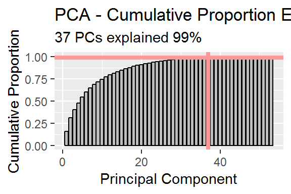

```r
preProcess <- prcomp(trclean[,-54], scale = TRUE)
VarianceExplained_prop <- data.frame(varexpl = preProcess$sdev^2/sum(preProcess$sdev^2), x = c(1:(dim(trclean)[2]-1)))

g2 = ggplot(data = VarianceExplained_prop, aes(x = x, y = cumsum(varexpl)))
g2 = g2 + geom_col(show.legend = FALSE, fill="grey", colour="black")
g2 = g2 + geom_hline(yintercept = 0.99, color = "#FF9999", size = 1.5)
g2 = g2 + geom_vline(xintercept = 37, color = "#FF9999", size = 1.5)
g2 = g2 + labs(title = "PCA - Cumulative Proportion Explained", y = "Cumulative Proportion",x = "Principal Component", subtitle = "37 PCs explained 99%")
g2
```

In the graph above we can see that 37 Principal components explain 99% of total variance. So it is clear that we will use PCA.

# Model selection and implementation

As the outcome **classe** implies predicting a category, the **Random Forest** could be a good option.

```r
## new train data
trdata <- data.frame(class = trclean$classe, preProcess$x)
## select outcome and the 37 PCs
trdata <- trdata[,1:38]
## Random Forest Model
rfmodel <- randomForest(class~., data = trdata)
## Doing Cross Validation
rf.cv <- rf.crossValidation(rfmodel, trdata, p=0.10, n=3)
```

```
## running: classification cross-validation with 3 iterations
```

```r
print(rfmodel)
```

```
##
## Call:
##  randomForest(formula = class ~ ., data = trdata)
##                Type of random forest: classification
##                      Number of trees: 500
## No. of variables tried at each split: 6
##
##         OOB estimate of  error rate: 1.38%
## Confusion matrix:
##      A    B    C    D    E class.error
## A 5570    5    1    2    2 0.001792115
## B   44 3728   20    2    3 0.018172241
## C    4   28 3369   19    2 0.015488019
## D    2    0   97 3111    6 0.032649254
## E    0    9   14   11 3573 0.009426116
```

```r
print(rf.cv)
```

```
## Classification accuracy for cross-validation
##
##                      A   B   C   D   E
## users.accuracy     100 100 100 100 100
## producers.accuracy 100 100 100 100 100
##
## Cross-validation Kappa = 1
## Cross-validation OOB Error = 0
## Cross-validation error variance = 1.06856e-09
##
##
## Classification accuracy for model
##
##                      A   B   C   D   E
## users.accuracy     100 100 100 100 100
## producers.accuracy 100 100 100 100 100
##
## Model Kappa = 1
## Model OOB Error = 0
## Model error variance = 1.06856e-09
```

```r
## Predict the training data and see the Confusion Matrix
rfpredictor <- predict(rfmodel, newdata = trdata)
confusionMatrix(rfpredictor, trdata$class)
```

```
## Confusion Matrix and Statistics
##
##           Reference
## Prediction    A    B    C    D    E
##          A 5580    0    0    0    0
##          B    0 3797    0    0    0
##          C    0    0 3422    0    0
##          D    0    0    0 3216    0
##          E    0    0    0    0 3607
##
## Overall Statistics
##
##                Accuracy : 1
##                  95% CI : (0.9998, 1)
##     No Information Rate : 0.2844
##     P-Value [Acc > NIR] : < 2.2e-16
##
##                   Kappa : 1
##  Mcnemar's Test P-Value : NA
##
## Statistics by Class:
##
##                      Class: A Class: B Class: C Class: D Class: E
## Sensitivity            1.0000   1.0000   1.0000   1.0000   1.0000
## Specificity            1.0000   1.0000   1.0000   1.0000   1.0000
## Pos Pred Value         1.0000   1.0000   1.0000   1.0000   1.0000
## Neg Pred Value         1.0000   1.0000   1.0000   1.0000   1.0000
## Prevalence             0.2844   0.1935   0.1744   0.1639   0.1838
## Detection Rate         0.2844   0.1935   0.1744   0.1639   0.1838
## Detection Prevalence   0.2844   0.1935   0.1744   0.1639   0.1838
## Balanced Accuracy      1.0000   1.0000   1.0000   1.0000   1.0000
```

We can see the model has great accuracy of near 1, so the model was a good selection and the expected out of sample error is near 0 (1- the model accuracy).

# Applying RF model in Test Data

We will use the same techinque applied to the training data.

```r
## Using PCA from training dataset in the test data
tsdata <- as.data.frame(predict(preProcess, newdata = tsclean))
rfresultstest <- predict(rfmodel, tsdata)
```

The results are B, A, B, A, A, E, D, B, A, A, B, C, B, A, E, E, A, B, B, B

# Conclusions

The use of PCA (Principal Components Analysis) and Random Forest has good results.